# Estudiantes en situación de desplazamiento en Santander

2023-12-07

## 0.1 Autores

Marlon Barajas Acelas

Luis Chaparro Castaño

# 1 Introducción

Con la intención de conocer esta información y dar a entender de una manera general y más sencilla la situación de los estudiantes desplazados en el departamento de Santander, se planean usar los datos proporcionados por el estado colombiano para el año 2022. Para responder a las preguntas generadas, se generarán las medidas estadísticas pertinentes con la ayuda de R y se explicarán los conceptos presentes en el conjunto de datos.

# 2 Paquetes de R requeridos

```r
library(readxl) #lectura de archivos de excel
library(tidyverse)  #manipulación y análisis de datos
library(skimr)  #resúmenes estadísticos para marcos de datos
library(DT) #presentación de tablas y conjuntos de datos
library(knitr)  #generación dinámica de reportes
library(kableExtra) #manipulación y creación de tablas
library(dplyr) #manipulación y creación de tablas
```

# 3 Preparación de los datos

## 3.1 Lectura y presentación de datos de origen

Los datos usados para el estudio son los proporcionados por el estado colombiano en [Estudiantes en situación de desplazamiento en Santander](https://www.datos.gov.co/Educaci-n/ESTUDIANTES-EN-SITUACI-N-DE-DESPLAZAMIENTO-EN-SANT/wemp-b8gd) cuya última actualización a la fecha es del 30 de septiembre de 2022.

```r
estudiantesDesplazados <- read_excel("ESTUDIANTES_EN_SITUACI_N_DE_DESPLAZAMIENTO_EN_SANTANDER.xlsx")
```

|  | d_ano | d_muni | d_nombmuni | d_provincia | d_nomsec | d_nomzon | dane_ant | d_nombinst | d_sede | d_nombsede | d_nomjor | d_grado | d_edad | d_genero | d_hombres | d_mujeres | d_tipo | metodo | sector | edad | etnia | discapa |
| --- | --- | --- | --- | --- | --- | --- | --- | --- | --- | --- | --- | --- | --- | --- | --- | --- | --- | --- | --- | --- | --- | --- |
| 1 | 2022 | 13 | AGUADA | VÉLEZ | OFICIAL | URBANA | 168013000016 | COLEGIO INTEGRADO ROEL Y VELASCO | 168013000016A | COLEGIO INTEGRADO ROEL Y VELASCO | MAÑANA | 1 | 7 | F | 0 | 1 | DESPLAZAMIENTO FORZADO | EDUCACION TRADICIONA | 1 | 7 | NINGUN GRUPO ETNICO | NO TIENE DISCAPACIDAD |
| 2 | 2022 | 13 | AGUADA | VÉLEZ | OFICIAL | URBANA | 168013000016 | COLEGIO INTEGRADO ROEL Y VELASCO | 168013000016A | COLEGIO INTEGRADO ROEL Y VELASCO | MAÑANA | 7 | 13 | F | 0 | 1 | EN SITUACION DE DESPLAZAMIENTO | EDUCACION TRADICIONA | 1 | 13 | NINGUN GRUPO ETNICO | NO TIENE DISCAPACIDAD |
| 3 | 2022 | 20 | ALBANIA | VÉLEZ | OFICIAL | URBANA | 168020000374 | COLEGIO DEPARTAMENTAL INTEGRADO SAGRADO CORAZON DE | 168020000374A | COLEGIO DEPARTAMENTAL INTEGRADO SAGRADO CORAZON DE | MAÑANA | 10 | 16 | F | 0 | 1 | EN SITUACION DE DESPLAZAMIENTO | EDUCACION TRADICIONA | 1 | 16 | NINGUN GRUPO ETNICO | NO TIENE DISCAPACIDAD |
| 4 | 2022 | 20 | ALBANIA | VÉLEZ | OFICIAL | URBANA | 168020000611 | COLEGIO DEPARTAMENTAL INTEGRADO SAGRADO CORAZON DE | 168020000374B | ESCUELA URBANA ULPIANO MUÑOZ | MAÑANA | 4 | 9 | M | 1 | 0 | VICTIMAS DE MINAS | EDUCACION TRADICIONA | 1 | 9 | NINGUN GRUPO ETNICO | NO TIENE DISCAPACIDAD |
| 5 | 2022 | 20 | ALBANIA | VÉLEZ | OFICIAL | RURAL | 268020000158 | COLEGIO DEPARTAMENTAL INTEGRADO SAGRADO CORAZON DE | 168020000374C | ESCUELA RURAL CANOAS | MAÑANA | 3 | 9 | M | 1 | 0 | EN SITUACION DE DESPLAZAMIENTO | ESCUELA NUEVA | 1 | 9 | NINGUN GRUPO ETNICO | NO TIENE DISCAPACIDAD |
| 6 | 2022 | 20 | ALBANIA | VÉLEZ | OFICIAL | RURAL | 268020000051 | COLEGIO DEPARTAMENTAL INTEGRADO SAGRADO CORAZON DE | 168020000374D | ESCUELA RURAL CANUTILLO | MAÑANA | 3 | 11 | M | 1 | 0 | HIJOS DE ADULTOS DESMOVILIZADO | ESCUELA NUEVA | 1 | 11 | NINGUN GRUPO ETNICO | NO TIENE DISCAPACIDAD |

Como se puede observar en los primeros seis registros, las variables más relevantes en los datos son:

| Variable | Descripcion |
| --- | --- |
| d_ano | Año del registro |
| d_muni | ID del municipio en el que se encuentra |
| d_nombmuni | Nombre del municipio en el que se encuentra |
| d_provincia | Nombre de la provincia en la que está ubicado |
| d_nomsec | Tipo de sector en el que se encuentra |
| d_nomzon | Tipo de zona en la que se encuentra |
| dane_ant | Código de ubicación geográfica de la institución |
| d_nombinst | Nombre de la institución en la cual está estudiando |
| d_sede | ID de la sede en la que se encuentra |
| d_nombsede | Nombre de la sede en la que está |
| d_nomjor | Jornada a la que asiste el estudiante |
| d_grado | Grado que cursa |
| d_edad | Edad del estudiante |
| d_genero | Género en formato de tipo caracter |
| d_hombres | Género en formato binario con 1 para masculino y 0 para femenino |
| d_mujeres | Género en formato binario con 0 para masculino y 1 para femenino |
| d_tipo | Razón o tipo de desplazamiento |
| metodo | Método por el cuál se brinda la educación |
| sector | Sector al que pertenece |
| etnia | Etnia a la que pertenece el estudiante |
| discapa | Discapacidad presente en el estudiante |

## 3.2 Limpieza de datos

La limpieza se hace con la intención de eliminar columnas repetidas o innecesarias, como por ejemplo para la edad del estudiante se presentan dos columnas distintas (d_edad y edad), o en el caso del género tres columnas con valores equivalentes (d_genero, d_hombres, d_mujeres). Además de esto se modificaron los valores de la variable “d_sede” para eliminar la repetición del código geográfico de la institución. Finalmente se renombraron las variables, para facilitar la lectura de los datos al público y se removió la variable d_ano puesto que todos los registros corresponden en su totalidad al actual año 2022.

```r
estudiantesDesplazados_clean <- estudiantesDesplazados %>%
  as_tibble(.) %>%
  select(-d_edad, -d_genero, -d_mujeres, -d_ano) %>%
  mutate(d_sede = str_sub(d_sede, -1)) %>%
  rename(ID_Municipio = d_muni, NombreMunicipio = d_nombmuni, Provincia = d_provincia, NombreSector = d_nomsec, Zona = d_nomzon, CódigoGeográfico = dane_ant, NombreInstitucion = d_nombinst, Sede = d_sede, NombreSede = d_nombsede, Jornada = d_nomjor, Grado = d_grado, Género = d_hombres, TipoDeDesplazamiento = d_tipo, MetodoEducación = metodo, Sector = sector, Edad = edad, Etnia = etnia, Discapacidad = discapa)

estudiantesDesplazados_clean <- estudiantesDesplazados_clean %>%
  mutate(ID_Municipio = as.numeric(ID_Municipio), CódigoGeográfico = as.numeric(CódigoGeográfico), Grado = as.numeric(Grado), Género = as.numeric(Género), Sector = as.numeric(Sector), Edad = as.numeric(Edad))
```

|  | ID_Municipio | NombreMunicipio | Provincia | NombreSector | Zona | CódigoGeográfico | NombreInstitucion | Sede | NombreSede | Jornada | Grado | Género | TipoDeDesplazamiento | MetodoEducación | Sector | Edad | Etnia | Discapacidad |
| --- | --- | --- | --- | --- | --- | --- | --- | --- | --- | --- | --- | --- | --- | --- | --- | --- | --- | --- |
| 1 | 13 | AGUADA | VÉLEZ | OFICIAL | URBANA | 168013000016 | COLEGIO INTEGRADO ROEL Y VELASCO | A | COLEGIO INTEGRADO ROEL Y VELASCO | MAÑANA | 1 | 0 | DESPLAZAMIENTO FORZADO | EDUCACION TRADICIONA | 1 | 7 | NINGUN GRUPO ETNICO | NO TIENE DISCAPACIDAD |
| 2 | 13 | AGUADA | VÉLEZ | OFICIAL | URBANA | 168013000016 | COLEGIO INTEGRADO ROEL Y VELASCO | A | COLEGIO INTEGRADO ROEL Y VELASCO | MAÑANA | 7 | 0 | EN SITUACION DE DESPLAZAMIENTO | EDUCACION TRADICIONA | 1 | 13 | NINGUN GRUPO ETNICO | NO TIENE DISCAPACIDAD |
| 3 | 20 | ALBANIA | VÉLEZ | OFICIAL | URBANA | 168020000374 | COLEGIO DEPARTAMENTAL INTEGRADO SAGRADO CORAZON DE | A | COLEGIO DEPARTAMENTAL INTEGRADO SAGRADO CORAZON DE | MAÑANA | 10 | 0 | EN SITUACION DE DESPLAZAMIENTO | EDUCACION TRADICIONA | 1 | 16 | NINGUN GRUPO ETNICO | NO TIENE DISCAPACIDAD |
| 4 | 20 | ALBANIA | VÉLEZ | OFICIAL | URBANA | 168020000611 | COLEGIO DEPARTAMENTAL INTEGRADO SAGRADO CORAZON DE | B | ESCUELA URBANA ULPIANO MUÑOZ | MAÑANA | 4 | 1 | VICTIMAS DE MINAS | EDUCACION TRADICIONA | 1 | 9 | NINGUN GRUPO ETNICO | NO TIENE DISCAPACIDAD |
| 5 | 20 | ALBANIA | VÉLEZ | OFICIAL | RURAL | 268020000158 | COLEGIO DEPARTAMENTAL INTEGRADO SAGRADO CORAZON DE | C | ESCUELA RURAL CANOAS | MAÑANA | 3 | 1 | EN SITUACION DE DESPLAZAMIENTO | ESCUELA NUEVA | 1 | 9 | NINGUN GRUPO ETNICO | NO TIENE DISCAPACIDAD |
| 6 | 20 | ALBANIA | VÉLEZ | OFICIAL | RURAL | 268020000051 | COLEGIO DEPARTAMENTAL INTEGRADO SAGRADO CORAZON DE | D | ESCUELA RURAL CANUTILLO | MAÑANA | 3 | 1 | HIJOS DE ADULTOS DESMOVILIZADO | ESCUELA NUEVA | 1 | 11 | NINGUN GRUPO ETNICO | NO TIENE DISCAPACIDAD |

# 4 Análisis exploratorio de datos

## 4.1 Edad y Grado

```
##    Min. 1st Qu.  Median    Mean 3rd Qu.    Max.
##    3.00   10.00   13.00   13.12   16.00   63.00
```

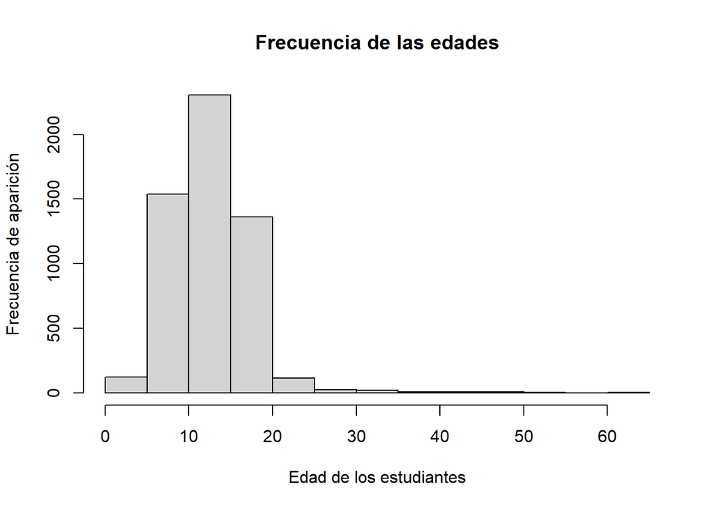

En un principio se podría pensar que la edad máxima presentada en esta variable corresponde a un outlayer, puesto que el número se aleja bastante de las demás medidas. Con la intención de estudiar esto se puede relacionar la edad con el grado.

```
##    Min. 1st Qu.  Median    Mean 3rd Qu.    Max.
##  -2.000   4.000   7.000   8.246  10.000  26.000
```

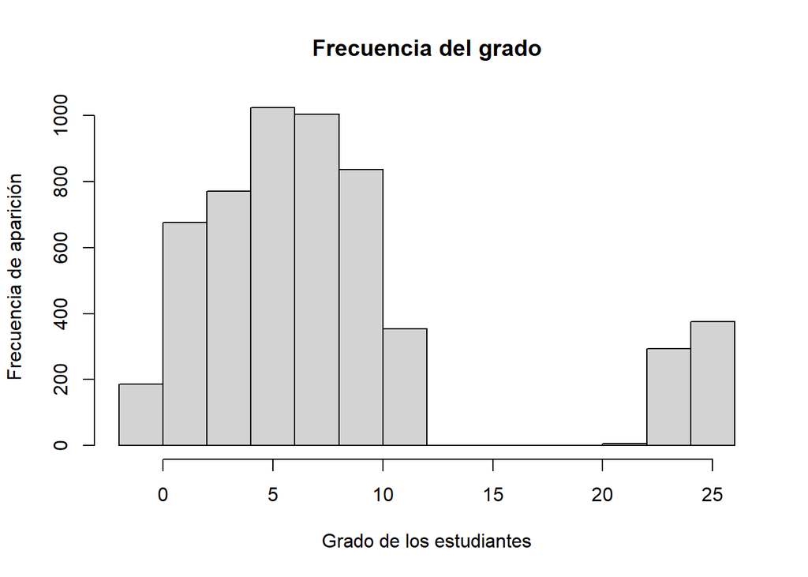

## 4.2 Relaciones con el método de ecuación

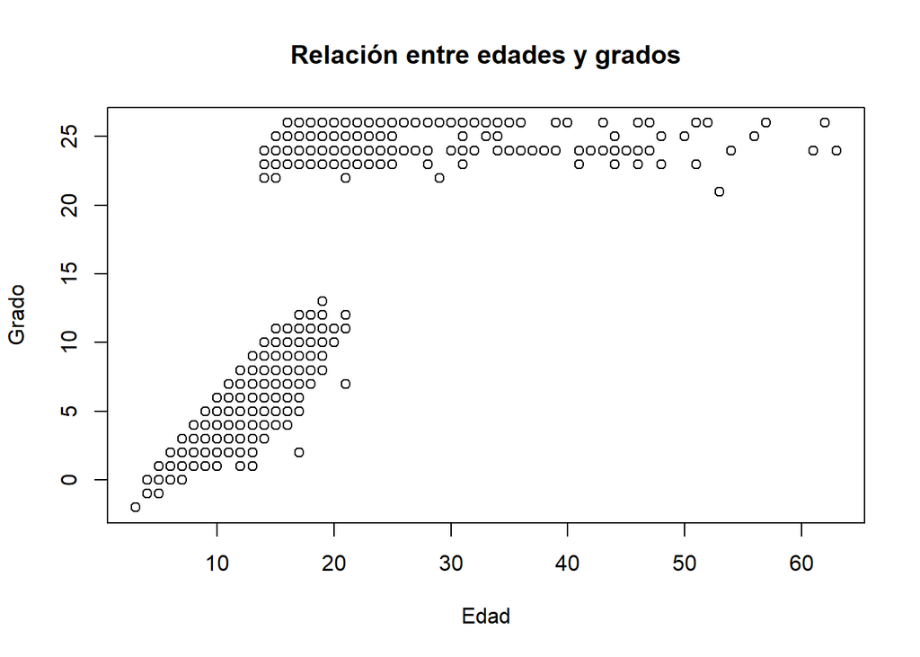

```r
plot(estudiantesDesplazados_clean$Edad, estudiantesDesplazados_clean$Grado, main = "Relación entre edades y grados", xlab = "Edad", ylab = "Grado", xlim = c(3,63), ylim = c(-2,26))
```

Esta figura permite ver que el número máximo de las edades no corresponde a un outlayer, sino a un integrante más de la población. De esta forma ciertos estudiantes con edades desde alrededor de los 14 años y hasta los 63 pertenecen a un grado distinto de escolaridad. En un principio esto puede ser algo raro, teniendo en cuenta que los grados convencionales en instituciones educativas del país van desde la educación primaria, hacia la media y hasta la secundaria (1 a 11).

Para poder explicar este fenómeno, se investigó sobre los diferentes tipos de educación que presta el gobierno para personas desplazadas. De esta forma los grados encontrados pueden pertenecer a uno o varios modelos educativos.

| Grado | ModelosEducativos |
| --- | --- |
| -2 | Educación tradicional, Escuela nueva, Etnoeducación, Preescolar escolarizado, Preescolar no escolarizado/semiescolarizado |
| -1 | Educación tradicional, Escuela nueva, Etnoeducación, Preescolar escolarizado, Preescolar no escolarizado/semiescolarizado |
| 0 | Educación tradicional, Escuela nueva, Etnoeducación, Preescolar escolarizado, Preescolar no escolarizado/semiescolarizado |
| 1 | Educación tradicional, Escuela nueva, Etnoeducación, Circulos de aprendizaje |
| 2 | Educación tradicional, Escuela nueva, Etnoeducación, Circulos de aprendizaje |
| 3 | Educación tradicional, Escuela nueva, Etnoeducación, Circulos de aprendizaje |
| 4 | Educación tradicional, Escuela nueva, Etnoeducación, Circulos de aprendizaje |
| 5 | Educación tradicional, Escuela nueva, Etnoeducación, Circulos de aprendizaje |
| 6 | Educación tradicional, PostPrimaria, Telesecundaria, Sistema de aprendizaje tutorial - SAT, Etnoeducación |
| 7 | Educación tradicional, PostPrimaria, Telesecundaria, Sistema de aprendizaje tutorial - SAT, Etnoeducación |
| 8 | Educación tradicional, PostPrimaria, Telesecundaria, Sistema de aprendizaje tutorial - SAT, Etnoeducación |
| 9 | Educación tradicional, PostPrimaria, Telesecundaria, Sistema de aprendizaje tutorial - SAT, Etnoeducación |
| 10 | Educación tradicional, PostPrimaria, Telesecundaria, Sistema de aprendizaje tutorial - SAT, Etnoeducación, Media rural |
| 11 | Educación tradicional, PostPrimaria, Telesecundaria, Sistema de aprendizaje tutorial - SAT, Etnoeducación, Media rural |
| 12 | Educación tradicional |
| 13 | Educación tradicional |
| 21 | Servicio de educación rural - SER, Programa de educación continuada - CAFAM, Programa para jóvenes en extraedad y adultos, SAT presencial, Transformemos, Modalidad virtual asistida - UCN, A crecer |
| 22 | Servicio de educación rural - SER, Programa de educación continuada - CAFAM, Programa para jóvenes en extraedad y adultos, SAT presencial, Transformemos, Modalidad virtual asistida - UCN, A crecer |
| 23 | Servicio de educación rural - SER, Programa de educación continuada - CAFAM, Programa para jóvenes en extraedad y adultos, SAT presencial, Transformemos, Grupos juveniles creativos, Modalidad virtual … |
| 24 | Servicio de educación rural - SER, Programa de educación continuada - CAFAM, Programa para jóvenes en extraedad y adultos, SAT presencial, Transformemos, Grupos juveniles creativos, Modalidad virtual … |
| 25 | Servicio de educación rural - SER, Programa de educación continuada - CAFAM, Programa para jóvenes en extraedad y adultos, SAT presencial, Transformemos, Grupos juveniles creativos, Modalidad virtual … |
| 26 | Servicio de educación rural - SER, Programa de educación continuada - CAFAM, Programa para jóvenes en extraedad y adultos, SAT presencial, Transformemos, Grupos juveniles creativos, Modalidad virtual … |

Teniendo esto en cuenta se posible separar los tipos de educación impartida que se muestran en el conjunto de datos.

```
## [1] "EDUCACION TRADICIONA" "ESCUELA NUEVA"        "PROGRAMA PARA JOVENE"
## [4] "POST PRIMARIA"        "MEDIA RURAL"          "SAT"
## [7] "CAMINAR EN SECUNDARI" "TEJIENDO SABERES"     "UNAD"
```

Para de esta forma asignar un valor a cada una, que se pueda relacionar con otras variables.

```r
estudiantesDesplazados_clean <- estudiantesDesplazados_clean %>%
  mutate(MetodoEducación = case_when(
    MetodoEducación == "EDUCACION TRADICIONA" ~ 1,
    MetodoEducación == "ESCUELA NUEVA" ~ 2,
    MetodoEducación == "PROGRAMA PARA JOVENE" ~ 3,
    MetodoEducación == "POST PRIMARIA" ~ 4,
    MetodoEducación == "MEDIA RURAL" ~ 5,
    MetodoEducación == "SAT" ~ 6,
    MetodoEducación == "CAMINAR EN SECUNDARI" ~ 7,
    MetodoEducación == "TEJIENDO SABERES" ~ 8,
    MetodoEducación == "UNAD" ~ 9
  )) %>%
  mutate(MetodoEducación = as.numeric(MetodoEducación))
```

### 4.2.1 Relación con la edad

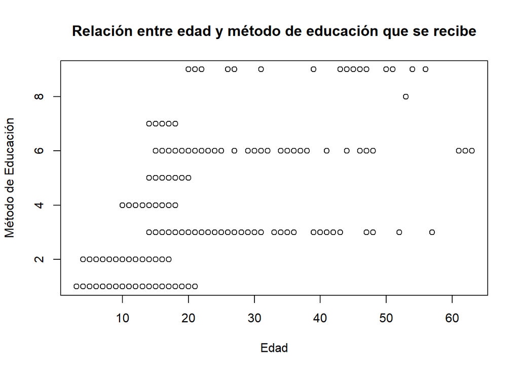

```r
plot(estudiantesDesplazados_clean$Edad, estudiantesDesplazados_clean$MetodoEducación, main = "Relación entre edad y método de educación que se recibe", xlab = "Edad", ylab = "Método de Educación", xlim = c(3,63), ylim = c(1,9))
```

# 5 Conclusiones

## 5.1 Educación

El tipo de educación impartida a los diferentes estudiantes en situación de desplazamiento puede variar incluso entre individuos con características similares, pero en términos generales, la educación tradicional está reservada para las personas más jóvenes y algunos adolescentes, para este último grupo también se ofrece la Escuela nueva, Postprimaria, Media rural y caminar en secundaria. Por último el programa para jovenes, el SAT, Tejiendo saberes y UNAD se ofrece generalmente a las personas con mayor edad en esta condición.

## 5.2 Edad

La edad no es un limitante para recibir educación en diferentes lugares del departamento, puesto que dada la cantidad de opciones disponibles es posible acomodar las condiciones educativas a diferentes personas, sin que lo impida su nivel de escolaridad, etnia u otros aspectos.

# 6 Bibliografía

Centro Nacional de Memoria HistC3rica. (2015). *Una NaciC3n Desplazada*. Una NaciC3n Desplazada. https://centrodememoriahistorica.gov.co/micrositios/desplazamientoForzado/

ComisiC3n de la verdad. (s. f.-a). *Desplazamiento Forzado*. Informe Final - ComisiC3n De La Verdad. https://www.comisiondelaverdad.co/violacion-derechos-humanos-y-derecho-internacional-humanitario/desplazamiento-forzado

gov.co. (2022). *ESTUDIANTES EN SITUACICN DE DESPLAZAMIENTO EN SANTANDER | Datos Abiertos Colombia*. www.datos.gov.co. https://www.datos.gov.co/Educaci-n/ESTUDIANTES-EN-SITUACI-N-DE-DESPLAZAMIENTO-EN-SANT/wemp-b8gd

mineducaci??n. (s. f.-b). *RELACI??N MODELO EDUCATIVO -GRADO*. Recuperado 7 de diciembre de 2023, de https://www.mineducacion.gov.co/1621/articles-255690_archivo_pdf_modelo_grado.pdf